# Yifan_Wu_HW4

Yifan Wu

February 19, 2018

# 4.7.6

## (a).

The logistic function for this problem shoule be in the following format:

$$P = \frac{e^{-6+0.05X_{1}+X_{2}}}{1+e^{-6+0.05X_{1}+X_{2}}}$$

We plug in $X_{1} = 40$ and $X_{2} = 3.5$ we get:

$$P = \frac{e^{-6+0.05\times 40 + 3.5}}{1+e^{-6+0.05\times 40 + 3.5}} = 0.3775$$

## (b).

The statement is equivalent to:

$\frac{e^{-6+0.05X_{1}+3.5}}{1+e^{-6+0.05X_{1}+3.5}} = 0.5 \Rightarrow X_{1} = 50$

# 4.7.13

First we split the dataset into training set and test set:

```r
library(ISLR)
library(MASS)
library(caret)
attach(Boston)

Boston$resp <- 0
Boston$resp[crim > median(crim)] <- 1
Boston$resp <-factor(Boston$resp)
table(Boston$resp)
```

```
##
##   0   1
## 253 253
```

```r
Boston <- Boston[-drop(1)]

inTrain <- createDataPartition(y = Boston$resp, p = 0.75, list = FALSE)

train <- Boston[inTrain,]
test <- Boston[-inTrain,]
```

```r
Cor <- cor(train[,-14])
Cor
```

```
##                  zn       indus        chas        nox          rm
## zn       1.00000000 -0.50997756 -0.07813635 -0.5062290  0.25181592
## indus   -0.50997756  1.00000000  0.08929842  0.7549364 -0.38955557
## chas    -0.07813635  0.08929842  1.00000000  0.1235809  0.09977497
## nox     -0.50622903  0.75493645  0.12358095  1.0000000 -0.31722954
## rm       0.25181592 -0.38955557  0.09977497 -0.3172295  1.00000000
## age     -0.56874807  0.62450699  0.13523195  0.7330303 -0.21400741
## dis      0.68164568 -0.69241934 -0.13236379 -0.7607523  0.16965025
## rad     -0.28740953  0.55632265  0.04618437  0.5817128 -0.18901015
## tax     -0.28989377  0.69420874  0.01471067  0.6478891 -0.28434370
## ptratio -0.34166511  0.34876262 -0.09552609  0.1427682 -0.33310773
## black    0.15407834 -0.32366443  0.05697209 -0.3712897  0.18257703
## lstat   -0.38361663  0.58867113 -0.05513332  0.5815110 -0.63124633
## medv     0.29412905 -0.44159098  0.17800133 -0.4048450  0.72417177
##                age        dis         rad         tax     ptratio
## zn      -0.5687481  0.6816457 -0.28740953 -0.28989377 -0.34166511
## indus    0.6245070 -0.6924193  0.55632265  0.69420874  0.34876262
## chas     0.1352319 -0.1323638  0.04618437  0.01471067 -0.09552609
## nox      0.7330303 -0.7607523  0.58171276  0.64788909  0.14276819
## rm      -0.2140074  0.1696502 -0.18901015 -0.28434370 -0.33310773
## age      1.0000000 -0.7481513  0.41706577  0.47393293  0.22221587
## dis     -0.7481513  1.0000000 -0.45908460 -0.50854743 -0.19586419
## rad      0.4170658 -0.4590846  1.00000000  0.90175904  0.44875403
## tax      0.4739329 -0.5085474  0.90175904  1.00000000  0.44357415
## ptratio  0.2222159 -0.1958642  0.44875403  0.44357415  1.00000000
## black   -0.2624618  0.2630225 -0.37207033 -0.38318417 -0.13597114
## lstat    0.5748879 -0.4732997  0.43126083  0.49987067  0.33284114
## medv    -0.3241043  0.1929604 -0.31923411 -0.41974564 -0.47680759
##               black       lstat       medv
## zn       0.15407834 -0.38361663  0.2941291
## indus   -0.32366443  0.58867113 -0.4415910
## chas     0.05697209 -0.05513332  0.1780013
## nox     -0.37128975  0.58151102 -0.4048450
## rm       0.18257703 -0.63124633  0.7241718
## age     -0.26246182  0.57488787 -0.3241043
## dis      0.26302248 -0.47329966  0.1929604
## rad     -0.37207033  0.43126083 -0.3192341
## tax     -0.38318417  0.49987067 -0.4197456
## ptratio -0.13597114  0.33284114 -0.4768076
## black    1.00000000 -0.36922029  0.2813013
## lstat   -0.36922029  1.00000000 -0.7265119
## medv     0.28130131 -0.72651188  1.0000000
```

```r
findCorrelation(Cor, cutoff = 0.80)
```

```
## [1] 9
```

We remove the column “tax” from our training data as well as test data because it is highly correlated with “rad”.

```r
train_cor <- train[,-drop(c(9))]
test_cor <- test[,-drop(c(9))]
```

Fitting the logistic regression model:

```r
logit <- train(resp~., data=train,
               method='glm', family=binomial(link='logit'),
               preProcess=c('scale', 'center'))
summary(logit)
```

```
##
## Call:
## NULL
##
## Deviance Residuals:
##     Min       1Q   Median       3Q      Max
## -2.1454  -0.1760  -0.0005   0.0043   3.3537
##
## Coefficients:
##             Estimate Std. Error z value Pr(>|z|)
## (Intercept)   2.2817     0.7349   3.105 0.001904 **
## zn           -1.8220     0.9245  -1.971 0.048750 *
## indus        -0.4570     0.3232  -1.414 0.157389
## chas          0.3486     0.2188   1.593 0.111120
## nox           5.2084     0.9340   5.576 2.46e-08 ***
## rm           -0.2680     0.5394  -0.497 0.619255
## age           0.6456     0.3902   1.655 0.098013 .
## dis           1.1383     0.5212   2.184 0.028960 *
## rad           5.5316     1.4866   3.721 0.000198 ***
## tax          -1.0318     0.4825  -2.138 0.032493 *
## ptratio       0.9497     0.2981   3.186 0.001444 **
## black        -0.7682     0.4932  -1.557 0.119377
## lstat         0.3226     0.3876   0.832 0.405194
## medv          1.2660     0.6230   2.032 0.042146 *
## ---
## Signif. codes:  0 '***' 0.001 '**' 0.01 '*' 0.05 '.' 0.1 ' ' 1
##
## (Dispersion parameter for binomial family taken to be 1)
##
##     Null deviance: 526.79  on 379  degrees of freedom
## Residual deviance: 168.21  on 366  degrees of freedom
## AIC: 196.21
##
## Number of Fisher Scoring iterations: 9
```

Test our model on testing set:

```r
confusionMatrix(predict(logit, test[,-14]), test$resp)
```

```
## Confusion Matrix and Statistics
##
##           Reference
## Prediction  0  1
##          0 58  6
##          1  5 57
##
##                Accuracy : 0.9127
##                  95% CI : (0.8492, 0.9556)
##     No Information Rate : 0.5
##     P-Value [Acc > NIR] : <2e-16
##
##                   Kappa : 0.8254
##  Mcnemar's Test P-Value : 1
##
##             Sensitivity : 0.9206
##             Specificity : 0.9048
##          Pos Pred Value : 0.9062
##          Neg Pred Value : 0.9194
##              Prevalence : 0.5000
##          Detection Rate : 0.4603
##    Detection Prevalence : 0.5079
##       Balanced Accuracy : 0.9127
##
##        'Positive' Class : 0
##
```

# Logistic regression homework Problem 1

```r
load("mnist_all.RData")

train_df = data.frame(train$x)
test_df = data.frame(test$x)

train_df$class = train$y
test_df$class = test$y

table(train_df$class)
```

```
##
##    0    1    2    3    4    5    6    7    8    9
## 5923 6742 5958 6131 5842 5421 5918 6265 5851 5949
```

Pull out the images that is 0 and 1.

```r
df_01 <- subset(train_df , class == 0 | class == 1)
table(df_01$class)
```

```
##
##    0    1
## 5923 6742
```

Do the same with test dataset:

```r
test_01 = subset(test_df , class == 0 | class == 1)
table(test_01$class)
```

```
##
##    0    1
##  980 1135
```

Get the column with the least number of 0 in it. It is pixel X213.

```r
#colSums(df_01 != 0)
df_count = data.frame(colSums(df_01 != 0))
colnames(df_count) = 'count'
which.max(df_count$count)
```

```
## [1] 213
```

Logistic regression:

```r
glm=glm(class ~ X213, data=df_01, family=binomial)
summary(glm)
```

```
##
## Call:
## glm(formula = class ~ X213, family = binomial, data = df_01)
##
## Deviance Residuals:
##     Min       1Q   Median       3Q      Max
## -1.6449  -1.0148   0.7734   1.1116   1.3569
##
## Coefficients:
##              Estimate Std. Error z value Pr(>|z|)
## (Intercept)  1.053783   0.035335   29.82   <2e-16 ***
## X213        -0.005751   0.000181  -31.78   <2e-16 ***
## ---
## Signif. codes:  0 '***' 0.001 '**' 0.01 '*' 0.05 '.' 0.1 ' ' 1
##
## (Dispersion parameter for binomial family taken to be 1)
##
##     Null deviance: 17504  on 12664  degrees of freedom
## Residual deviance: 16413  on 12663  degrees of freedom
## AIC: 16417
##
## Number of Fisher Scoring iterations: 4
```

```r
test_01_X213 = data.frame(X213 = test_01$X213)

glm.probs = predict(glm, newdata = test_01_X213)
glm.pred=rep(0,length(glm.probs))
glm.pred[glm.probs >.5] = 1



confusionMatrix(glm.pred, test_01$class)
```

```
## Confusion Matrix and Statistics
##
##           Reference
## Prediction   0   1
##          0 743 617
##          1 237 518
##
##                Accuracy : 0.5962
##                  95% CI : (0.5749, 0.6172)
##     No Information Rate : 0.5366
##     P-Value [Acc > NIR] : 1.96e-08
##
##                   Kappa : 0.209
##  Mcnemar's Test P-Value : < 2.2e-16
##
##             Sensitivity : 0.7582
##             Specificity : 0.4564
##          Pos Pred Value : 0.5463
##          Neg Pred Value : 0.6861
##              Prevalence : 0.4634
##          Detection Rate : 0.3513
##    Detection Prevalence : 0.6430
##       Balanced Accuracy : 0.6073
##
##        'Positive' Class : 0
##
```

Summary of the model:

```r
summary(glm)
```

```
##
## Call:
## glm(formula = class ~ X213, family = binomial, data = df_01)
##
## Deviance Residuals:
##     Min       1Q   Median       3Q      Max
## -1.6449  -1.0148   0.7734   1.1116   1.3569
##
## Coefficients:
##              Estimate Std. Error z value Pr(>|z|)
## (Intercept)  1.053783   0.035335   29.82   <2e-16 ***
## X213        -0.005751   0.000181  -31.78   <2e-16 ***
## ---
## Signif. codes:  0 '***' 0.001 '**' 0.01 '*' 0.05 '.' 0.1 ' ' 1
##
## (Dispersion parameter for binomial family taken to be 1)
##
##     Null deviance: 17504  on 12664  degrees of freedom
## Residual deviance: 16413  on 12663  degrees of freedom
## AIC: 16417
##
## Number of Fisher Scoring iterations: 4
```

Here the inercept term is: 1.05 and the slope term for X213 is -0.006.

The logistic regression equation is:

$$p(X) = \frac{e^{1.05 -0.006 X213}}{1 + e^{1.05 -0.006 X213}}$$

```r
library(pROC)
```

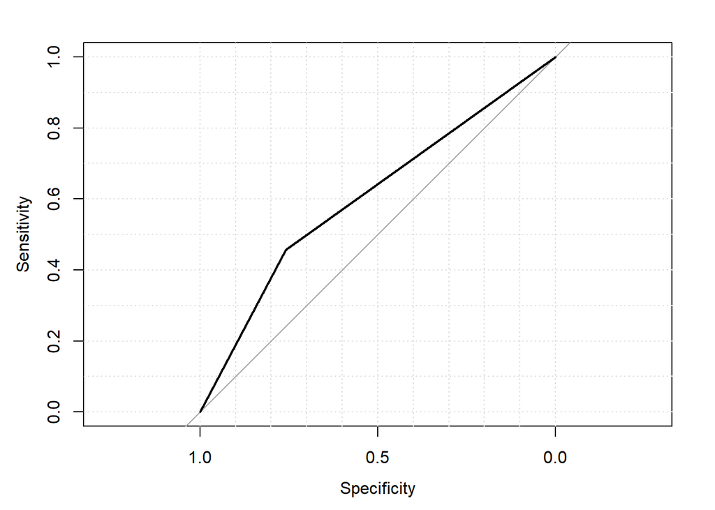

```
##
## Call:
## roc.formula(formula = test_01$class ~ glm.pred, plot = TRUE,     grid = TRUE, show.thres = TRUE)
##
## Data: glm.pred in 980 controls (test_01$class 0) < 1135 cases (test_01$class 1).
## Area under the curve: 0.6073
```

```r
roc(test_01$class ~ glm.pred,plot = TRUE, grid = TRUE, show.thres = TRUE)
```

The fraction of true positives if the fraction of false positives is 0.1(specificity = 0.9) is about 0.2. The model is doing slightly better than pure guessing and the same could be derived from the result of the confusion matrix.

# Logistic regression homework Problem 2

```r
cor(df_01$X500, df_01$X601)
```

```
## [1] 0.09957491
```

Fit logistic regression to the data:

```r
glm2=glm(class ~ X500 + X601, data=df_01, family=binomial)
summary(glm2)
```

```
##
## Call:
## glm(formula = class ~ X500 + X601, family = binomial, data = df_01)
##
## Deviance Residuals:
##     Min       1Q   Median       3Q      Max
## -1.7155  -1.1548   0.7222   0.9810   7.0086
##
## Coefficients:
##               Estimate Std. Error z value Pr(>|z|)
## (Intercept)  1.2107252  0.0369907   32.73   <2e-16 ***
## X500        -0.0964829  0.0072687  -13.27   <2e-16 ***
## X601        -0.0049965  0.0001916  -26.08   <2e-16 ***
## ---
## Signif. codes:  0 '***' 0.001 '**' 0.01 '*' 0.05 '.' 0.1 ' ' 1
##
## (Dispersion parameter for binomial family taken to be 1)
##
##     Null deviance: 17504  on 12664  degrees of freedom
## Residual deviance: 14264  on 12662  degrees of freedom
## AIC: 14270
##
## Number of Fisher Scoring iterations: 9
```

```r
test_01_low_cor = data.frame(X500 = test_01$X500,X601 = test_01$X601)

glm2.probs = predict(glm2, newdata = test_01_low_cor)
glm2.pred=rep(0,length(glm2.probs))
glm2.pred[glm2.probs >.5] = 1



confusionMatrix(glm2.pred, test_01$class)
```

```
## Confusion Matrix and Statistics
##
##           Reference
## Prediction   0   1
##          0 765 531
##          1 215 604
##
##                Accuracy : 0.6473
##                  95% CI : (0.6265, 0.6677)
##     No Information Rate : 0.5366
##     P-Value [Acc > NIR] : < 2.2e-16
##
##                   Kappa : 0.306
##  Mcnemar's Test P-Value : < 2.2e-16
##
##             Sensitivity : 0.7806
##             Specificity : 0.5322
##          Pos Pred Value : 0.5903
##          Neg Pred Value : 0.7375
##              Prevalence : 0.4634
##          Detection Rate : 0.3617
##    Detection Prevalence : 0.6128
##       Balanced Accuracy : 0.6564
##
##        'Positive' Class : 0
##
```

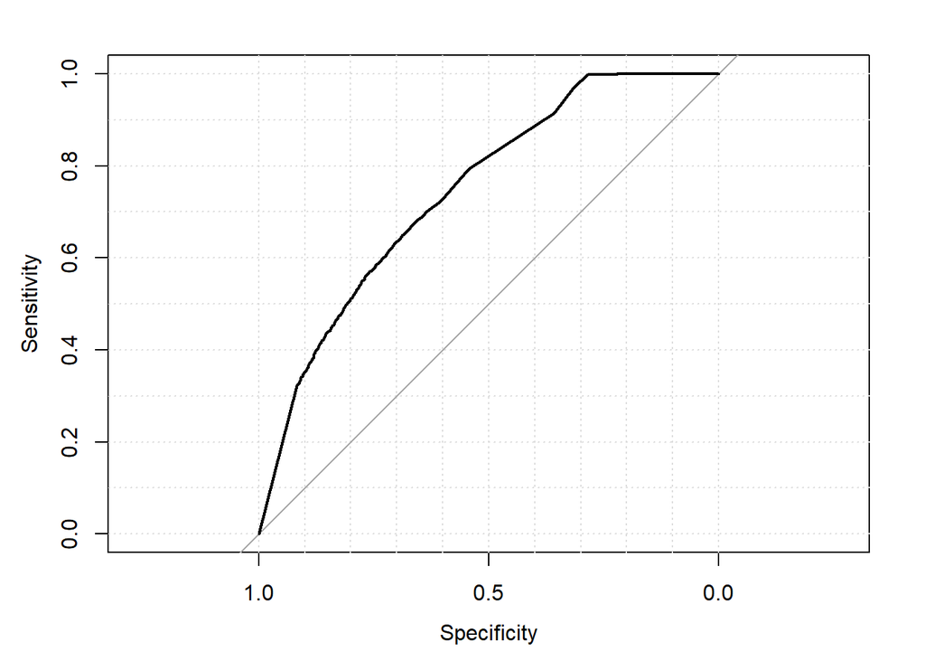

```
##
## Call:
## roc.formula(formula = class ~ prob, data = df_01, plot = TRUE,     grid = TRUE)
##
## Data: prob in 5923 controls (class 0) < 6742 cases (class 1).
## Area under the curve: 0.7448
```

```r
library(pROC)
prob=predict(glm2,type=c("response"))
df_01$prob=prob
roc(class ~ prob, plot = TRUE, grid = TRUE, data = df_01)
```

From the ROC curve we can see that our model goes above the y = x line so our data is applicable and does better than pure chance.

In the training set:

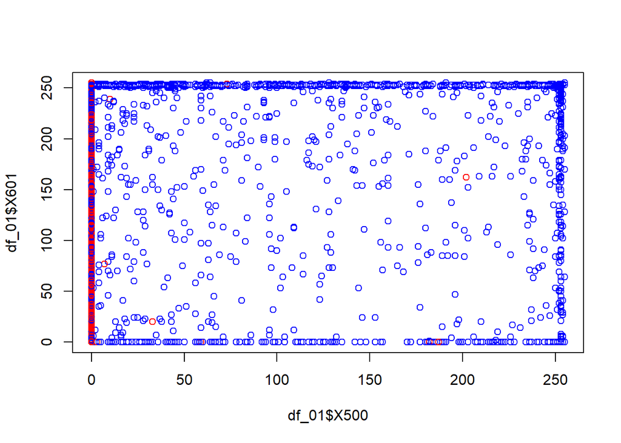

```r
# Create new column filled with default colour
df_01$Colour="black"
# Set new column values to appropriate colours
df_01$Colour[df_01$class == 0]="blue"
df_01$Colour[df_01$class == 1]="red"
plot(df_01$X500, df_01$X601, col=df_01$Colour)
```

In the trianing dataset, most of the pictture with a white X500 pixel are 1 but not all of it. It might affect the performance of the regression fitting because the patter is not obvious. We need to increase the dimentionality of the predictors to get a more precice prediction result.

# Logistic regression homework Problem 3

First we find out the variance for all of the columns in the trianing dataframe and sout out the columns that has the highest variance.

```r
var = sort(apply(df_01[,c(-785,-786, -787)], 2, var),decreasing = TRUE)
var_df = data.frame(var)
cols = row.names(head(var_df, 10))
```

Then fit logistic regression with those 10 variables as predictors:

```r
glm3=glm(class ~ X407 + X435 + X379 + X463 + X462 + X352 + X351 + X380 + X490 + X434 , data=df_01, family=binomial)
summary(glm3)
```

```
##
## Call:
## glm(formula = class ~ X407 + X435 + X379 + X463 + X462 + X352 +
##     X351 + X380 + X490 + X434, family = binomial, data = df_01)
##
## Deviance Residuals:
##     Min       1Q   Median       3Q      Max
## -3.9196  -0.0958   0.0320   0.0535   3.2821
##
## Coefficients:
##              Estimate Std. Error z value Pr(>|z|)
## (Intercept) -5.381427   0.173351 -31.043  < 2e-16 ***
## X407         0.005319   0.002554   2.083 0.037295 *
## X435         0.006364   0.002467   2.579 0.009904 **
## X379         0.002766   0.002561   1.080 0.280096
## X463         0.011875   0.001722   6.898 5.27e-12 ***
## X462         0.006390   0.002615   2.444 0.014531 *
## X352         0.001963   0.001781   1.102 0.270501
## X351         0.002624   0.001865   1.407 0.159352
## X380         0.008275   0.001852   4.468 7.90e-06 ***
## X490        -0.001590   0.001871  -0.850 0.395532
## X434         0.007240   0.001893   3.823 0.000132 ***
## ---
## Signif. codes:  0 '***' 0.001 '**' 0.01 '*' 0.05 '.' 0.1 ' ' 1
##
## (Dispersion parameter for binomial family taken to be 1)
##
##     Null deviance: 17504.4  on 12664  degrees of freedom
## Residual deviance:  1130.5  on 12654  degrees of freedom
## AIC: 1152.5
##
## Number of Fisher Scoring iterations: 8
```

```r
test_01_var = data.frame(X407 = test_01$X407,
                         X435 = test_01$X435,
                         X379 = test_01$X379,
                         X463 = test_01$X463,
                         X462 = test_01$X462,
                         X352 = test_01$X352,
                         X351 = test_01$X351,
                         X380 = test_01$X380,
                         X490 = test_01$X490,
                         X434 = test_01$X434)

glm3.probs = predict(glm3, newdata = test_01_var)
glm3.pred=rep(0,length(glm3.probs))
glm3.pred[glm3.probs >.5] = 1



confusionMatrix(glm3.pred, test_01$class)
```

```
## Confusion Matrix and Statistics
##
##           Reference
## Prediction    0    1
##          0  973   18
##          1    7 1117
##
##                Accuracy : 0.9882
##                  95% CI : (0.9826, 0.9923)
##     No Information Rate : 0.5366
##     P-Value [Acc > NIR] : <2e-16
##
##                   Kappa : 0.9762
##  Mcnemar's Test P-Value : 0.0455
##
##             Sensitivity : 0.9929
##             Specificity : 0.9841
##          Pos Pred Value : 0.9818
##          Neg Pred Value : 0.9938
##              Prevalence : 0.4634
##          Detection Rate : 0.4600
##    Detection Prevalence : 0.4686
##       Balanced Accuracy : 0.9885
##
##        'Positive' Class : 0
##
```

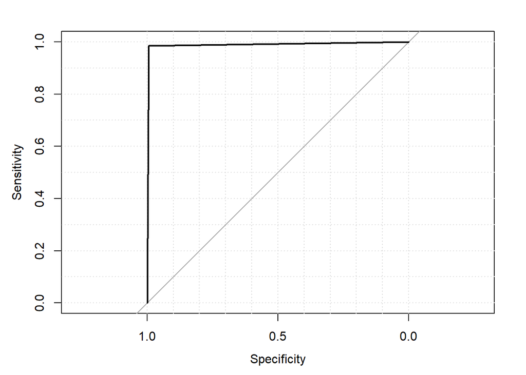

```
##
## Call:
## roc.formula(formula = test_01$class ~ glm3.pred, plot = TRUE,     grid = TRUE, show.thres = TRUE)
##
## Data: glm3.pred in 980 controls (test_01$class 0) < 1135 cases (test_01$class 1).
## Area under the curve: 0.9885
```

```r
roc(test_01$class ~ glm3.pred,plot = TRUE, grid = TRUE, show.thres = TRUE)
```

As we can see from the ROC curve, our model is doing very well and it almost reaches to 1 for both bounds. So the model that uses 10 variables that has most variance does extremely well in differentiating 0 from 1.